# Get on the Trail! PIC16B Final Project Overview

project

Author

Zion Gassner

Published

March 22, 2024

# Project Location Information:

## Blog Post:

https://torwar02.github.io/pic16b/posts/16B%20Final%20Project/

## Github Repository:

https://github.com/torwar02/trails

# Project Overview

Using the internet, it’s very easy to find information about hiking trails throughout the United States, but there’s a problem: it’s a lot easier to browse through lists of trails available online, like on the website trailforks.com, and filtering by location. What are you supposed to do if you don’t know much about an area but still want to go hiking, or what if you want to do certain things on your hike but don’t know where to go? You could do lots of research online yourself, reading articles or sifting through different locations, but this process can be very difficult, especially if you want to go somewhere that you’ve never been.

Our project addresses finding new places to visit based upon what type of hiking trails the user wants to see (which the user would describe) based upon previously hiked trails. For instance, if the user previously hiked Half Dome in Yosemite, then we give the user other trails and locations in the United States most similar to Half Dome according to reviews on TripAdvisor. This would be mainly for tourists who want to visit parts of the country they have not been to.

Before we dive into how individual aspects of our project were created, let’s go over a brief overview of what we’re going to be doing.

## Brief Summary

There are websites were you can get nitty-gritty information about trails. There are websites where you can read about people’s experiences at parks. Why not combine the two to see where you want to go on your next adventure? That’s why the pipeline for this project looks something like this:

[figure not shown]

Image1

TrailForks contains information about both parks and individual trails. Most of the information is numerical: how long a trail is, how many trails a park has, the difficulty, things like that. Because there’s a lot of infromation here, we’ve stored it in a SQL database. TripAdvisor contains reviews and photos, and scraped information will be directly put into the recommendation system.

First, I have taken part of Tyler’s writeup here to show how he took data from TripAdvisor and then used it to create a recommendation system. Then, we will look at the TrailForks scraping and SQL datbabase aspect before looking at how we can combine the information from TrailForks with the recommendation. Finally, we will see how the information is stored on the website, as well as a look at an image matting tool that’s also on it.

```python
import matplotlib.pyplot as plt
import pandas as pd
```

# Webscraping Trip Advisor - Tyler

Here we webscrape TripAdvisor to gather reviews for semantic analysis such that we can recommend trails based upon how similar reviews are to each other. We do so using scrapy!

This is what the first page looks like:

[figure not shown]

The first function we write is `parse`. This function redirects users from the general national park page to the page with just activities to do.

```python
def parse(self, response):
    next_page = response.xpath("//div//a[contains(@href, 'Attraction')]//@href").get() #xpath command to redirect to activities
    yield response.follow(next_page, callback = self.parse_full_credits) #redirects to the new url page and executes parse_full_credits
```

The second function we write is `parse_full_credits`. This function redirects users from the list of all activities to each individual trail page. We do this so that we can extract reviews and information of individual trails per national park.

This is what the second page looks like:

[figure not shown]

Image3

```python
def parse_full_credits(self, response):
trail_page = response.xpath("//div[@class = 'BYvbL A']//a[@class = 'BUupS _R w _Z y M0 B0 Gm wSSLS']//@href").getall()
    for trail in trail_page: #for every trail in the trial page list url, execute the callback command parse_actor_page
        yield response.follow(trail, callback = self.parse_trail)
```

Finally, the last function we write is `parse_trail`. This function outputs important data such as National Park name, state national park is in, trail name, overall trail rating, title of comment, text of comment, and individual comment rating.

```python
def parse_trail(self, response):
    national_park = response.xpath("//span[@class = 'fxMOE']//text()").get()
    state = response.xpath("//span[@class = 'n q']//span[@class = 'biGQs _P pZUbB avBIb osNWb']//text()").getall()[1]
    trail = response.xpath("//h1//text()").get()
    comment_title = response.xpath("//div[@class = 'LbPSX']//div[@class = 'biGQs _P fiohW qWPrE ncFvv fOtGX']//span//text()").getall()
    ratings = response.xpath("//div[@class = 'LbPSX']//svg[@class = 'UctUV d H0']//title//text()").getall()
    comment_text = response.xpath("//div[@class = 'LbPSX']//span[@class = 'JguWG']//span[@class = 'yCeTE']//text()[1]").getall()
    pictures = response.xpath("//div[@class = 'LbPSX']//span[@class = 'biGQs _P XWJSj Wb']//img//@srcset").getall()
    overall_rating = response.xpath("//div[@class = 'biGQs _P fiohW hzzSG uuBRH']//text()").get()
    trail_type = response.xpath("//div[@class = 'biGQs _P pZUbB alXOW oCpZu GzNcM nvOhm UTQMg ZTpaU W KxBGd']//span//text()").get()
    for ix in range(len(comment_title)):
        yield {
          "national_park" : national_park,
          "state" : state,
          "trail":trail,
          "activity": trail_type,
          "overall_rating": overall_rating,
          "comment_title":comment_title[ix],
          "comment_ratings":ratings[ix],
          "comment_text":comment_text[ix]
        }
```

This is what the trail page with reviews looks like:

[figure not shown]

Image4

Now, we want to get this data in `csv` format. To do so, we go to the directory which holds our spider and run `scrapy crawl trip_advisor -o national_parks.csv`. Great, now we can analyze our reviews!

# Review Similarity Trail Recommender - Tyler

Now, we utilize functions and word embedding to return the most similar trails and their location in the United States based upon the csv file we just created from our webscraper!

```python
import pandas as pd
import numpy as np
from matplotlib import pyplot as plt
import gensim
import spacy
```

```python
nlp = spacy.load('en_core_web_sm')
```

## Load Data

Now let us load the data we scraped by TripAdvisor as well as a Excel file containing coordinate points of our national parks so that we can create a geograpical plot later

```python
df = pd.read_csv('https://raw.githubusercontent.com/torwar02/trails/main/trails/national_parks.csv')
```

```python
df2 = pd.read_excel('https://raw.githubusercontent.com/torwar02/trails/main/trails/coords.xlsx')
```

```python
df.head()
```

|  | national_park | state | trail | activity | overall_rating | comment_title | comment_ratings | comment_text |
| --- | --- | --- | --- | --- | --- | --- | --- | --- |
| 0 | Acadia National Park | Maine (ME) | Beech Mountain Trail | Hiking Trails | 4.5 | Turned back on 3/20/21 due to ice | 4.0 of 5 bubbles | I have hiked to the fire tower a few times. It... |
| 1 | Acadia National Park | Maine (ME) | Beech Mountain Trail | Hiking Trails | 4.5 | Spectacular | 5.0 of 5 bubbles | This trail was recommended in my Acadia travel... |
| 2 | Acadia National Park | Maine (ME) | Beech Mountain Trail | Hiking Trails | 4.5 | Great Trail | 5.0 of 5 bubbles | Beech Mountain Trail is one of my favorites in... |
| 3 | Acadia National Park | Maine (ME) | Beech Mountain Trail | Hiking Trails | 4.5 | Best trail in Acadia | 5.0 of 5 bubbles | We stumbled onto this trail and were very happ... |
| 4 | Acadia National Park | Maine (ME) | Beech Mountain Trail | Hiking Trails | 4.5 | Great trail for family | 5.0 of 5 bubbles | My family has kids ranging from age 10 to 3. W... |

```python
df2.head()
```

|  | Latitude | Longitude | Park | State(s) | Park Established | Area | Visitors (2018) |
| --- | --- | --- | --- | --- | --- | --- | --- |
| 0 | 44.35 | -68.21 | Acadia | Maine | February 26, 1919 | 49,075.26 acres (198.6 km2) | 3537575 |
| 1 | -14.25 | -170.68 | American Samoa | American Samoa | October 31, 1988 | 8,256.67 acres (33.4 km2) | 28626 |
| 2 | 38.68 | -109.57 | Arches | Utah | November 12, 1971 | 76,678.98 acres (310.3 km2) | 1663557 |
| 3 | 43.75 | -102.50 | Badlands | South Dakota | November 10, 1978 | 242,755.94 acres (982.4 km2) | 1008942 |
| 4 | 29.25 | -103.25 | Big Bend | Texas | June 12, 1944 | 801,163.21 acres (3,242.2 km2) | 440091 |

To merge the two files together, we utilize regex. Get string preceding ‘National Park’ in df such that we can merge with df2 on National Park name

```python
import re
pattern = r'(.*?)(?:\s+National Park)?$'
result = re.findall(pattern, df['national_park'].iloc[0])
park = []
for row in df['national_park']:
    test_park = re.findall(pattern, row)
    park.append(test_park[0])
df['park'] = park
national_parks = pd.merge(df, df2, left_on='park', right_on='Park')
national_parks = national_parks.drop(columns = ['park', 'Park', 'State(s)', 'Park Established'])
national_parks.head()
```

|  | national_park | state | trail | activity | overall_rating | comment_title | comment_ratings | comment_text | Latitude | Longitude | Area | Visitors (2018) |
| --- | --- | --- | --- | --- | --- | --- | --- | --- | --- | --- | --- | --- |
| 0 | Acadia National Park | Maine (ME) | Beech Mountain Trail | Hiking Trails | 4.5 | Turned back on 3/20/21 due to ice | 4.0 of 5 bubbles | I have hiked to the fire tower a few times. It... | 44.35 | -68.21 | 49,075.26 acres (198.6 km2) | 3537575 |
| 1 | Acadia National Park | Maine (ME) | Beech Mountain Trail | Hiking Trails | 4.5 | Spectacular | 5.0 of 5 bubbles | This trail was recommended in my Acadia travel... | 44.35 | -68.21 | 49,075.26 acres (198.6 km2) | 3537575 |
| 2 | Acadia National Park | Maine (ME) | Beech Mountain Trail | Hiking Trails | 4.5 | Great Trail | 5.0 of 5 bubbles | Beech Mountain Trail is one of my favorites in... | 44.35 | -68.21 | 49,075.26 acres (198.6 km2) | 3537575 |
| 3 | Acadia National Park | Maine (ME) | Beech Mountain Trail | Hiking Trails | 4.5 | Best trail in Acadia | 5.0 of 5 bubbles | We stumbled onto this trail and were very happ... | 44.35 | -68.21 | 49,075.26 acres (198.6 km2) | 3537575 |
| 4 | Acadia National Park | Maine (ME) | Beech Mountain Trail | Hiking Trails | 4.5 | Great trail for family | 5.0 of 5 bubbles | My family has kids ranging from age 10 to 3. W... | 44.35 | -68.21 | 49,075.26 acres (198.6 km2) | 3537575 |

## Word Embedding and Comment Similarity Score

First let us go over what Word Embedding is. Word embedding in NLP is an important technique that is used for representing words for text analysis in the form of real-valued vectors. In this approach, words and documents are represented in the form of numeric vectors allowing similar words to have similar vector representations. The extracted features are fed into a machine learning model so as to work with text data and preserve the semantic and syntactic information. This information once received in its converted form is used by NLP algorithms that easily digest these learned representations and process textual information.

### Comment Similarity Function

Now let us create a function called `comment_similarity` which takes in our `national_parks.csv` file we just created via the `park_data` parameter, a `comment_index` parameter, and an `all_comments` parameter which is our word embedding vector representation of all comments in our csv file.

```python
all_docs = [nlp(row) for row in national_parks['comment_text']] #getting vector representation of all comments in our csv file
```

```python
def comment_similarity(parks_data, comment_index, all_comments):
    example_comment = parks_data.loc[comment_index, 'comment_text']
    reference_comment = nlp(example_comment) #vectorize our reference sentence
    simularity_score = []
    row_id = []
    for i in range(len(all_comments)):
        sim_score = all_comments[i].similarity(reference_comment)
        simularity_score.append(sim_score)
        row_id.append(i)
    simularity_docs = pd.DataFrame(list(zip(row_id, simularity_score)), columns = ['Comment_ID', 'sims'])
    simularity_docs_sorted = simularity_docs.sort_values(by = 'sims', ascending = False)
    most_similar_comments = simularity_docs_sorted['Comment_ID'][1:2]
    new_reviews = national_parks.iloc[most_similar_comments.values]
    return(new_reviews)
```

Now let us show what our returned dataframe looks like

```python
showcase = comment_similarity(national_parks, 0, all_docs)
showcase
```

|  | national_park | state | trail | activity | overall_rating | comment_title | comment_ratings | comment_text | Latitude | Longitude | Area | Visitors (2018) |
| --- | --- | --- | --- | --- | --- | --- | --- | --- | --- | --- | --- | --- |
| 2129 | Mesa Verde National Park | Colorado (CO) | Mesa Verde National Park | National Parks | 4.5 | Very unusual and very enjoyable. | 5.0 of 5 bubbles | This review should be most helpful to visitors... | 37.18 | -108.49 | 52,485.17 acres (212.4 km2) | 563420 |

First the original comment

```python
example_comment = national_parks.loc[0, 'comment_text']
example_comment
```

```
"I have hiked to the fire tower a few times. Its a great hike, and not too strenuous elevation gains.  If the NO rangers are up there ( in the summer) they used to allow you to go up the tower. We had to turn back on 3/20 because of hard pack solid ice. We had our Katoohla micro spikes on, and solid…
```

Now the similar comment.

```python
showcase['comment_text'].iloc[0]
```

```
"This review should be most helpful to visitors who wish to do minimal hiking/walking, who enjoy spending most of the time driving, or who do not plan to pay for any of the popular tours of the ruins. We had a wonderful experience even without the tours. We arrived at the park the day they started s…
```

### Total Trail Simularity

```python
def total_similarity(trail, parks_data, all_comments):
    trail_subset = parks_data[parks_data['trail'] == trail].index
    total_df = []
    for number in trail_subset:
        total_df.append(comment_similarity(national_parks, number, all_docs))
    df = pd.concat(total_df)
    return(df)
```

```python
output = total_similarity("Landscape Arch", national_parks, all_docs)
output
```

|  | national_park | state | trail | activity | overall_rating | comment_title | comment_ratings | comment_text | Latitude | Longitude | Area | Visitors (2018) |
| --- | --- | --- | --- | --- | --- | --- | --- | --- | --- | --- | --- | --- |
| 1492 | Grand Canyon National Park | Arizona (AZ) | Grand Canyon Desert View Watchtower | Observation Decks & Towers | 4.5 | Great views and shop - be aware of COVID limit... | 5.0 of 5 bubbles | This area is either your first stop on the way... | 36.06 | -112.14 | 1,201,647.03 acres (4,862.9 km2) | 6380495 |
| 655 | Canyonlands National Park | Utah (UT) | Horseshoe Canyon | Canyons | 5.0 | A challenging hike with Native American Art re... | 5.0 of 5 bubbles | Horseshoe Canyon is difficult to access, possi... | 38.20 | -109.93 | 337,597.83 acres (1,366.2 km2) | 739449 |
| 655 | Canyonlands National Park | Utah (UT) | Horseshoe Canyon | Canyons | 5.0 | A challenging hike with Native American Art re... | 5.0 of 5 bubbles | Horseshoe Canyon is difficult to access, possi... | 38.20 | -109.93 | 337,597.83 acres (1,366.2 km2) | 739449 |
| 727 | Canyonlands National Park | Utah (UT) | Grand View Point Overlook | Lookouts | 5.0 | freaking amazing! | 5.0 of 5 bubbles | Don't miss this. | 38.20 | -109.93 | 337,597.83 acres (1,366.2 km2) | 739449 |
| 1369 | Glacier National Park | Montana (MT) | Virginia Falls | Waterfalls | 5.0 | A Must See !! | 5.0 of 5 bubbles | We parked by St Mary’s Fall’s parking. It took... | 48.80 | -114.00 | 1,013,125.99 acres (4,100.0 km2) | 2965309 |
| 3027 | Yosemite National Park | California (CA) | Sentinel Dome | Geologic Formations | 5.0 | THE view at Yosemite! | 5.0 of 5 bubbles | This is the place to come for views if you onl... | 37.83 | -119.50 | 761,747.50 acres (3,082.7 km2) | 4009436 |
| 1063 | Channel Islands National Park | California (CA) | The Sea Caves | Caverns & Caves | 5.0 | A unique and awesome experience! | 5.0 of 5 bubbles | My wife and I camped 2 nights at Scorpion Harb... | 34.01 | -119.42 | 249,561.00 acres (1,009.9 km2) | 366250 |
| 3291 | Zion National Park | Utah (UT) | Kolob Canyons | Canyons | 4.5 | Choose Kolob to avoid the Zion crowds | 5.0 of 5 bubbles | This is a great alternative to the very crowde... | 37.30 | -113.05 | 147,237.02 acres (595.8 km2) | 4320033 |
| 3291 | Zion National Park | Utah (UT) | Kolob Canyons | Canyons | 4.5 | Choose Kolob to avoid the Zion crowds | 5.0 of 5 bubbles | This is a great alternative to the very crowde... | 37.30 | -113.05 | 147,237.02 acres (595.8 km2) | 4320033 |
| 650 | Canyonlands National Park | Utah (UT) | Horseshoe Canyon | Canyons | 5.0 | WHOA! READ PLEASE. Things you NEED to know a... | 5.0 of 5 bubbles | There are some older reviews. Some are VERY M... | 38.20 | -109.93 | 337,597.83 acres (1,366.2 km2) | 739449 |

### Plotly Function

Now let us construct a geographical plot function called `plotting_parks` to get the location of these trails on a map. This is so that the user can better visualize where in the United States they may have to travel to. The function also analyzes other metrics from `national_parks.csv` such as visitors in 2018, type of activity, trail name, and overall TripAdvisor rating. This function calls `total_similarity` in order to get the dataframe with the most similar reviews!

```python
from plotly import express as px
import plotly.io as pio
import inspect
pio.renderers.default="iframe"
```

```python
def plotting_parks(trail, parks_data, all_comments, **kwargs):
    output = total_similarity(trail, parks_data, all_comments)
    fig = px.scatter_mapbox(output, lon = "Longitude", lat = "Latitude", color = "overall_rating",
                        color_continuous_midpoint = 2.5, hover_name = "national_park", height = 600,
                        hover_data = ["Visitors (2018)", "activity", "trail", "overall_rating"],
                        title = "Recommended National Park Trails",
                        size_max=50,
                        **kwargs,
                        )
    return fig
```

```python
color_map = px.colors.diverging.RdGy_r # produce a color map
fig = plotting_parks("Landscape Arch", national_parks, all_docs, mapbox_style="carto-positron",
                                   color_continuous_scale = color_map)
```

```python
fig.show()
```

[interactive chart not shown]

Great, as we can see, we get a geo plot of the most similar National Park trails in the United States to `Landscape Arch`!

# Webscraping TrailForks - Zion

Okay, so that’s one source of data taken care of! Now, let’s look at another: TrailForks.

Our original plan was to use a website called AllTrails which contains very comprehensive information about different hiking trails. Nonetheless, they beefed up their security measures several years ago to prevent people from scraping their website Because of this, we turned to a different site called TrailForks that, while still able to block `scrapy`, is unable to block Selenium.

## How do you get started with Selenium?

Selenium is able to evade certain anti-bot measures by actually using an instance of a web browser (called a webdriver) that runs on your system while scraping. In fact, once you get the scraper to work, you can actually watch it run in real time! Unfortunately, that makes it a lot slower than `scrapy`, for instance, because your computer actually has to manually open every page. I used a Google Chrome webdriver. Below is (part of) the head of the `scraper.py` function which scrapes data from individual trails from TrailForks.

```python
from selenium.webdriver.common.keys import Keys
from selenium.webdriver.common.by import By
from selenium.webdriver.chrome.service import Service
import pandas as pd
from selenium import webdriver


chrome_options = webdriver.ChromeOptions()
options = webdriver.ChromeOptions()
options.add_experimental_option(
        "prefs", {
            # block image loading
            "profile.managed_default_content_settings.images": 2,
            "profile.managed_default_content_settings.javascript": 2
        }
    )
driver = webdriver.Chrome(
        service=service,
        options=options
    )
chrome_options.add_argument('--no-sandbox')
chrome_options.add_argument('--headless')
```

Of note are the experimental options under `prefs` which block both images and javascript content from loading on a website. When I first made the scraper, I did not have these enabled, and a result, sometimes pages would take between 3 and 5 seconds to load (way too long!). Similarly, the `--headless` argument also make the pages load faster by disabling certain Google Chrome functionalities: `https://www.selenium.dev/blog/2023/headless-is-going-away/`

## How do you scrape using Selenium?

At its core, Selenium isn’t that different from `scrapy` in that you can have a scraper download HTML code which you can then filter through in Python as more familiar objects. Both `scraper.py` and `scraper_parks.py` (which filters through park-related information on TrailForks) have the same general principles: 1. Look at what state a user has inputted 2. Get links to all of the park/trail pages for that state 3. Get corresponding information from each page, using helper functions if need be 4. Add data to SQL database (see next section for that!)

# `scraper.py`

As an example, let’s take a look at the function `state_scraper` in `scraper.py`. This is the outermost scraping function and takes in a state that the user inputs. However, for our project, we just used it to grab trails from California, since it would’ve taken a very long time to do this for the entire country, given that TrailForks has nearly 300,000 trails registered in the US alone.

```python
def state_scraper(state_name):
    """
    This is the primary scraping function used inside of `main`.

    Inputs:
    ``href_list``: A list of each state's current page's trail urls, compiled by `main`
    ``state_name``: The name of the state in question.

    The function iterates through each url in ``href_list`` and using selenium's Chrome
    driver, it gets the `url` and calls the 3 individual scraping function: `scrape_basic_stats`,
    `scrape_tables` (twice--once for trail information and one for trail statistics), and
    `get_names_coords`. Once all of the information is gathered into dictionaries, they are
    combined and added into `trails.db`.

    """
    start_url = f"https://www.trailforks.com/region/{state_name}/trails//?activitytype=6&region=3106"
    url_list = [start_url]

    for page_num in range(state_page_dict[state_name]):
        url_list.append(start_url + f"&page={page_num+2}")

    for page_num in range(state_page_dict[state_name]):
        href_list = []
        driver.get(url_list[page_num])
        green_links = driver.find_elements("xpath","//tr//a[contains(@class, 'green')]")

        for green in green_links:
            href = green.get_attribute("href") #Grab URLs--otherwise this doesn't work
            href_list.append(href)


        for url in href_list:
            trail_keywords = ["Activities", "Riding Area", "Difficulty Rating", "Local Popularity"]
            stats_keywords = ["Altitude start", "Altitude end", "Grade"]
            basic_vars_dict = {"Distance": ["NA"], "Avg time": ["NA"], "Climb": ["NA"], "Descent": ["NA"]}
            trail_details_vars = {"Activities": ["NA"], "Riding Area": ["NA"], "Difficulty Rating": ["NA"], "Local Popularity": ["NA"]}
            trail_stats_vars = { "Altitude start": ["NA"], "Altitude end": ["NA"], "Grade": ["NA"]}
            name_coord_dict = {'Name': ["NA"],'Coords': ["NA"]}
            print(url)
            driver.get(url)
            basic_vars = scrape_basic_stats(basic_vars_dict)
            trail_stats = scrape_tables(stats_keywords, 'trailstats_display', trail_stats_vars)
            trail_details = scrape_tables(trail_keywords, 'traildetails_display', trail_details_vars)
            names_coords = get_names_coords(name_coord_dict)

            database_info.add_trails(pd.DataFrame({**names_coords,**basic_vars, **trail_details, **trail_stats}),state_name)

    driver.quit()
```

There’s a lot going on here! I’ll attach screenshots from TrailForks here to make it easier to follow along. The first thing that we do is establish a starting url which we get from TrailForks thanks to an f-string that contains the name of the state that we want. We then append that url to a url list. This list is important because we couldn’t actually get this to work without having it, since going `back` and `forward` is a bit harder in Selenium than it is in `scrapy`.

Then, we store the urls for all of the trail list pages that correspond to a given state, which on the website, looks like this:

[figure not shown]

Image_TrailForks

The numbers come from a dictionary saved in `database_info.py`. Before making `scraper.py`, I scraped the page numbers.

Then, on each page, we grab the urls to individual trails. Note that Selenium uses a class called `driver` to interface with the page that it’s scraping, and the key methods here are called `get` (which just navigates to the page) and `find_elements`, which has two arguments. The first argument specifies *how* the scraper should interpret the second argument, which is some sort of instruction. For example, when we grab all of the links on the page to the trails, we use

```python
 driver.find_elements("xpath","//tr//a[contains(@class, 'green')]")
```

where the second input is an xpath instruction that `find_elements` can read thanks to the fact that the first argument is simply a string that says `xpath`. There’s a lot of documentation for `xpath` available online, which I started to investigate for the movie database homework assignment. This website came in handy: https://www.w3schools.com/xml/xpath_syntax.asp

In the above example, we grab all links (`a`) contained in all table rows (`tr`) given that they are of class `green` (not sure why they’re calle that, but links to trails are of that class). Once we actually load it into python, though, we have to call

```python
for green in green_links:
           href = green.get_attribute("href") #Grab URLs--otherwise this doesn't work
           href_list.append(href)
```

in a `for` loop to specifically take out the link portion of each `a` and then add it to the URL list.

## Individual Scraping Functions

Now we can get to the fun part. We essentially give a set of instructions to go to each trail’s page armed with a set of both lists containing keywords as well as dictionaries. The idea here is to search for specific variables stored in each trail and then update the value inside of the corresponding dictionary. As you can see, we split this task into four parts:

```python
basic_vars = scrape_basic_stats(basic_vars_dict)
           trail_stats = scrape_tables(stats_keywords, 'trailstats_display', trail_stats_vars)
           trail_details = scrape_tables(trail_keywords, 'traildetails_display', trail_details_vars)
           names_coords = get_names_coords(name_coord_dict)
```

Let’s go over each one briefly.

### `scraper_basic_stats`

`scraper_basic_stats` takes the `basic_vars_dict` as an input:

```python
def scrape_basic_stats(basic_vars_dict):
    """
    This function should be called within the `state_scraper` function.

    Inputs:
    ``basic_vars_dict``: a dictionary with the relevant variable names as keys and, by default,
    `NA` as values.

    On a given trail's website, it will find a `div` element of id `basicTrailStats`.
    This is a table containing information about the trail's length, average time to
    completion, ascent, and descent, if those variables are available.
    The function looks for `div`s of ID `padded10` which contain `col-3` class `div`s.
    The name of each variable is the `text` of the `small.grey` class within each `col-3`.
    The variable's value is stored in the `text` of `div` `large` or `large hovertip`

    The function uses conditional statements as not all of the variables are available.
    """
    try:
        basic_stats_div = driver.find_element(By.ID, "basicTrailStats")

        padded10_divs = basic_stats_div.find_elements(By.CLASS_NAME, "padded10")

        for padded10_div in padded10_divs:
            col_3_divs = padded10_div.find_elements(By.CLASS_NAME, "col-3")
            for col_3_div in col_3_divs:
                small_grey_div = col_3_div.find_element(By.CLASS_NAME, "small.grey")
                variable_name = small_grey_div.text
                large_div = col_3_div.find_element(By.CSS_SELECTOR, ".large, .large.hovertip")
                variable_value = large_div.text
                if variable_name in basic_vars_dict:
                    basic_vars_dict[variable_name] = variable_value
    except:
        pass
    return basic_vars_dict
```

This function essentialy looks for the light gray box at the top of each trail’s page which has some basic information like distance, climb, descent, and average completion time. This box has an ID of `basicTrailStats` (see how we use `find_element` with `By.ID`?) and contains a `div` called `padded10`, which in turn contains `divs` of `col-3`. These essentially work like dictionaries. Each one has a `div` of class `large` and `small grey` (note that we use periods here) whose text contains the information we want.

We have to make sure that each variable that we want is in our dictionary and that furthermore, it’s present on the trail page. Some trails have sparse or non-existent information for certain variables, and as a result, the specified variables simply don’t exist. This is also why this (and all other) helper function has its body in a `try/except` format, since it’s possible for `basicTrailStats` to not exist at all (only on rare occasions).

### `scrape_tables`

```python
def scrape_tables(var_list, element_id, var_dict):
    """
    This function is used within `state_scraper` to access `ul`s with variable information.

    Inputs:
    ``var_list``: a list ofthe relevant variable names.
    ``element_id``: the `id` of the `ul` in question--there are two which need to be scraped.
    ``var_dict``: a dictionary with the relevant variable names as keys and, by default,
    `NA` as values.

    Each `ul` contains `li`s formatted like a dictionary with a `div` of class `term`,
    which stores variable names, and a `div` of class `definition` which stores variable
    values. Both `div`s store the key information in their `text`. Since not all variables
    are needed, we check if they are in ``var_list`` before assigning them to
    ``var_dict``'s values.

    """
    try:
        li_elements = driver.find_elements("xpath", f"//ul[contains(@id, '{element_id}')]//li")
        for li_element in li_elements:
            term_div = li_element.find_elements(By.CLASS_NAME, "term")
            definition_div = li_element.find_elements(By.CLASS_NAME, "definition")
            for idx, terms in enumerate(term_div):
                if terms.text in var_list:
                    var_dict[terms.text] = [definition_div[idx].text]

    except:
        pass
    return var_dict
```

This function is called twice in the body of the scraper because there are two similarly structured tables (one with general trail information and one with more detailed statistics) that we want to grab certain variables from. The tables are unordered lists (`ul`s) which contain list elements (`li`s) that we can conveniently loop through by using the `find_elements` function which automatically converts it into a python iterable (similarly to `scrapy`). The lists are once again sorted like dictionaries, in fat, they contain classes called `terms` and `definitions`, which we then parse through one by one and use to update *our* dictionary, which is then returned.

### `get_names_coords()`

```python
def get_names_coords(name_coord_dict):
  """
  This function is used within `state_scraper` to access each trail's name and coordinates.

  Inputs:
  ``name_coord_dict``: a dictionary with keys `Name` and `Coords`. By default, the values are `NA`

  The function grabs the trail's name from a `span` of class `translate` from the top of the page.
  It also grabs the coordinates from a `span` of class `grey2` within a `div` of class
  `margin-bottom-15`. The coordinates are stored in the `span`'s `text`.
  """
  try:
      name_raw = driver.find_element("xpath", "//span[contains(@class, 'translate')][1]")
      name_coord_dict['Name'] = [name_raw.text]
  except:
      name_coord_dict['Name'] = "NA"
  try:
      coord_raw = driver.find_element("xpath", "//div[contains(@class, 'margin-bottom-15 grey')]/span[contains(@class, 'grey2')][2]") #Get coords
      name_coord_dict['Coords'] = coord_raw.text
  except:
      name_coord_dict['Coords'] = "NA"

  return name_coord_dict
```

This is a bit more of a miscellaneous function, since it’s not dedicated to any one purpose. All it does is store the name of the trail as well as its coordinates. These are stored as two different classes of `div`s found on different parts of the page. Then, we just grab their `text`. Simple as that!

Once we grab all of that information, we add it to our SQL datbase:

```python
database_info.add_trails(pd.DataFrame({**names_coords,**basic_vars, **trail_details, **trail_stats}),state_name)
```

which I’ll talk about in the next section. Here’s a brief image overview of what our scraper does:

[figure not shown]

Image6

# scraper_parks.py

This file also contains a function called `state_scraper` which once again takes a state’s name as its input, but this time, it’s focused on collecting information about *parks* rather than trails (on TrailForks, there are many trails within one park). I was able to run this to get some numerical data about parks throughout the US (including national parks) which was then integrated into the website and recommender system.

This time, I don’t use helper functions (rather, I just keep it in the `state_scraper`’s body), so we’ll go through it bit by bit. Firstly, it’s worth going over what we actually want from each park’s page:

1. Each park’s name and location
2. The number of trails in each park, how long the trails are, and the popularity ranking.
3. How many trails there are of each difficulty

## Set-up

The settings for Selenium are the same as in the last case. The pre-scraping part is almost identical as well:

```python
start_url = f"https://www.trailforks.com/region/{state_name}/ridingareas/?activitytype=6"
    url_list = [start_url]

    for page_num in range(database_info.state_dictionary[state_name]):
        url_list.append(start_url + f"&page={page_num+2}")

    for page_num in range(state_page_dict[state_name]):
        href_list = []
        driver.get(url_list[page_num])
        green_links = driver.find_elements("xpath","//tr//a[contains(@class, 'green')]")

        for green in green_links:
            href = green.get_attribute("href") #Grab URLs--otherwise this doesn't work
            href_list.append(href+"/?activitytype=6")
```

Once again, I pre-scraped the number of pages required per state, though because there are fewer parks than trails, it wasn’t as big of a load on my computer.

## Names and coordinates

Here’s the first part of where we actually scrape:

```python
 for url in href_list:
            no_name_found = False
            info_dict = {"Name":["NA"], "Location":["NA"], "Coords":["NA"]}
            stats_dict =  {"Trails (view details)":["NA"],"Total Distance":["NA"], "State Ranking":["NA"],}
            trail_difficulty_count = {"Access Road/Trail":0,"White":0,"Green":0,"Blue":0,"Black":0,"Double Black Diamond":0, "Proline":0}
            print(url)
            driver.get(url)
            area_name_raw = driver.find_element("xpath", "//span[contains(@class, 'translate')][1]")
            info_dict["Name"] = area_name_raw.text
            try:
                city_name_raw = driver.find_element(By.CLASS_NAME, "small.grey2.mobile_hide")
                info_dict["Location"] = city_name_raw.text
            except:
                no_name_found = True
```

We create our three dictionaries that we want for each URL. The `print(url)` function is present as a debugging tool since, unfortunately, this scraper crashed multiple times due to unfixed bugs (which I eventually patched out, mostly due to elements not being present).

We get the name of the trail by finding a `span` with class `translate` (not sure why it’s stored like that, it’s actually within an `h1` within a `ul` called `page_title_container`). Then, we try to look for the name of the city that it’s in by grabbing a small piece of text that’s next to the park’s name. Sometimes, this isn’t present, which is why we have a bool called `no_name_found` in case it’s not. There’s a way around this, though, which we’ll show later…

### Ranking, Distance, and Trail numbers:

```python
    stats_items = ["State Ranking", "Total Distance", "Trails (view details)"]
            dict_category = driver.find_elements("xpath", "//dl//dt")
            dict_information = driver.find_elements("xpath", "//dl//dd")

            for idx, terms in enumerate(dict_category):
                if terms.text in stats_items:
                    stats_dict[terms.text] = [dict_information[idx].text]

            try:
                difficulty_ul = driver.find_element(By.CLASS_NAME, 'stats.flex.nostyle.inline.clearfix')

                for li in difficulty_ul.find_elements(By.TAG_NAME, 'li'):
                    difficulty_span = li.find_element(By.XPATH, './/span[contains(@class, "stat-label clickable")]/span')
                    difficulty_name = difficulty_span.get_attribute('title')
                    if difficulty_name in trail_difficulty_count.keys():
                        num_trails_span = li.find_element(By.CLASS_NAME, 'stat-num')
                        num_trails = int(num_trails_span.text)
                        trail_difficulty_count[difficulty_name] = num_trails
```

The code here is somewhat dense thanks to the fact that all of this information is stored in a dictionary-like object called a `dl` which, in turn, has something like a key in a `dl` and something like a value in a `dd`. Essentially, we update the ranking and trail distances by inspecting these.

It’s a little bit harder to get the number of trails per difficulty. Basically, there’s an unordered list with a long class name (`'stats.flex.nostyle.inline.clearfix'` that sorts the number of trails by difficulty. Each `li` has the number of trails stored within it, but it also has a graphic that represents the difficulty (it’s a small picture), and it’s the graphic that actually hides the name of the difficulty, which is why we have to extract `difficulty_name` from a `span` of class `stat-label clickable`. Then, we simply grab the actual text that displays how many trails of a given difficulty there are, convert it to an integer, and then add it to our dictionary.

### Coordinates

One of the unfortunate parts of the parks list is that the coordinates of each park are not present! To get around this, we tell the scraper to go to the first trail in each park and grab its coordinates (remember `scraper.py`?) and then store it.

```python
  try:
                green_link = driver.find_element("xpath","//tr//a[contains(@class, 'green')]")
                park_link = green_link.get_attribute("href")
                driver.get(park_link)
            except:
                pass

            try:
                coord_raw = driver.find_element("xpath", "//div[contains(@class, 'margin-bottom-15 grey')]/span[contains(@class, 'grey2')][2]") #Get coords
                info_dict['Coords'] = [coord_raw.text]
                if no_name_found:
                    city_name_raw = driver.find_element(By.CLASS_NAME, "weather_date bold green")
                    info_dict["Location"] = city_name_raw.text
            except:
                info_dict['Coords'] = ["NA"]
```

It’s here where we also resolve the issue of when we can’t find a city’s name. Basically, on each trail’s page, there’s a short infobox containing weather information for the nearest city which is *guaranteed* to appear, so we can get an approximate location name precisely by grabbing the city name from this box.

Here’s another image of what the scraper in action looks like:

[figure not shown]

ImageScraperParks

Once we’re done with that, it’s off to the database again!

# SQL Database - Zion

There’s a lot of information that we scrape from TrailForks which has to be managed within a SQL datbase for easy access. For example, California has more than 16,000 trails, and for each trail, we collected 12 variables (see above), so that means that there’s more than 192,000 entries! We used `sqlite3` to easily manage a database, or rather, two: one is called `trails.db` and contains individual trails (specifically, those in California, though our original plan was to include the entire country), and one called `trails_new.db` (now that I think about it, I probably should’ve given it a different name) which contains park information, where each state has a different table.

## database_info.py

Everything relevant to managing the datbase is stored in a different python file called `database_info.py`. Here I can show you the structure of both databases:

### Making the databases

```python
def make_db(state):
    conn = sqlite3.connect("trails.db")
    cmd = f"""
    CREATE TABLE IF NOT EXISTS {state_name_code_name_dict[state]}(
    name VARCHAR(255),
    coords VARCHAR(255),
    Distance VARCHAR(255),
    'Avg time' VARCHAR(255),
    Climb VARCHAR(255),
    Descent VARCHAR(255),
    Activities VARCHAR(255),
    'Riding Area' VARCHAR(255),
    'Difficulty Rating' VARCHAR(255),
    'Dogs Allowed' VARCHAR(255),
    'Local Popularity' VARCHAR(255),
    'Altitude start' VARCHAR(255),
    'Altitude end' VARCHAR(255),
    Grade VARCHAR(255)
    );
    """
    cursor = conn.cursor()
    cursor.execute(cmd)
    cursor.close()
    conn.close()

def make_db_parks(state):
    conn = sqlite3.connect("trails_new.db")
    cmd = f"""
    CREATE TABLE IF NOT EXISTS {state_name_code_name_dict[state]}(
    Name VARCHAR(255),
    Location VARCHAR(255),
    Coords VARCHAR(255),
    'Trails (view details)' SMALLINT(255),
    'Total Distance' VARCHAR(255),
    'State Ranking' VARCHAR(255),
    'Access Road/Trail' SMALLINT(255),
    White SMALLINT(255),
    Green SMALLINT(255),
    Blue SMALLINT(255),
    Black SMALLINT(255),
    'Double Black Diamond' SMALLINT(255),
    Proline SMALLINT(255)
    );
    """
    cursor = conn.cursor()
    cursor.execute(cmd)
    cursor.close()
    conn.close()
```

These two functions were run in order to actually create the datbaase for the first time. They contain the variables as mentioned previously, mostly in the form of text.

### Adding information

If you recall from the scraping functions, there was a function call that would add information from each park to the SQL database. Here’s the source code for those functions:

```python
def get_db():
    conn = sqlite3.connect("trails.db")
    return conn

def add_trails(df,state):
    conn = get_db()
    df.to_sql(state, conn, if_exists = "append", index = False)

def get_db_new():
    conn = sqlite3.connect("trails_new.db")
    return conn

def add_trails_new(df,state):
    conn = get_db_new()
    df.to_sql(state, conn, if_exists = "append", index = False)
```

The functions `get_db` and `get_db_new` (most things relating to `scraper_parks` are labeled `new` since we did this second) establish connections to their respective databases. `add_trails` and `add_trails_new`, therefore, are actually responsible for adding entries to each database. Note that they take a `df` as one input (which contains the scraped info) and a state name, which sends the information to the correct table.

### Miscellaneous Tables

There are several dictionaries and lists that we generated in order to make the functions easier to run:

```python
states = ["Alabama", "Alaska", "Arizona", "Arkansas", "California", "Colorado", "Connecticut", "Delaware", "Florida", "Georgia", "Hawaii", "idaho-3166", "Illinois", "Indiana", "Iowa", "Kansas", "Kentucky", "Louisiana", "Maine", "Maryland", "Massachusetts", "Michigan", "Minnesota", "Mississippi", "Missouri", "Montana", "Nebraska", "Nevada", "new-hampshire", "new-jersey", "new-mexico", "new-york", "north-carolina", "north-dakota", "Ohio", "Oklahoma", "Oregon", "Pennsylvania", "rhode-island", "south-carolina", "south-dakota", "Tennessee", "Texas", "Utah", "Vermont", "Virginia", "Washington", "west-virginia", "Wisconsin", "Wyoming"]

state_name_code_name_dict = {
    'Alabama': 'Alabama',
    'Alaska': 'Alaska',
    'Arizona': 'Arizona',
    'Arkansas': 'Arkansas',
    'California': 'California',
    'Colorado': 'Colorado',
    'Connecticut': 'Connecticut',
    'Delaware': 'Delaware',
    'Florida': 'Florida',
    'Georgia': 'Georgia',
    'Hawaii': 'Hawaii',
    'idaho-3166': 'Idaho',
    'Illinois': 'Illinois',
    'Indiana': 'Indiana',
    'Iowa': 'Iowa',
    'Kansas': 'Kansas',
    'Kentucky': 'Kentucky',
    'Louisiana': 'Louisiana',
    'Maine': 'Maine',
    'Maryland': 'Maryland',
    'Massachusetts': 'Massachusetts',
    'Michigan': 'Michigan',
    'Minnesota': 'Minnesota',
    'Mississippi': 'Mississippi',
    'Missouri': 'Missouri',
    'Montana': 'Montana',
    'Nebraska': 'Nebraska',
    'Nevada': 'Nevada',
    'new-hampshire': 'NewHampshire',
    'new-jersey': 'NewJersey',
    'new-mexico': 'NewMexico',
    'new-york': 'NewYork',
    'north-carolina': 'NorthCarolina',
    'north-dakota': 'NorthDakota',
    'Ohio': 'Ohio',
    'Oklahoma': 'Oklahoma',
    'Oregon': 'Oregon',
    'Pennsylvania': 'Pennsylvania',
    'rhode-island': 'RhodeIsland',
    'south-carolina': 'SouthCarolina',
    'south-dakota': 'SouthDakota',
    'Tennessee': 'Tennessee',
    'Texas': 'Texas',
    'Utah': 'Utah',
    'Vermont': 'Vermont',
    'Virginia': 'Virginia',
    'Washington': 'Washington',
    'west-virginia': 'WestVirginia',
    'Wisconsin': 'Wisconsin',
    'Wyoming': 'Wyoming'
}


state_dictionary = {'Alabama': 11, 'Alaska': 11, 'Arizona': 49, 'Arkansas': 16, 'California': 152, 'Colorado': 69, 'Connecticut': 56, 'Delaware': 4, 'Florida': 18, 'Georgia': 17, 'Hawaii': 5, 'idaho-3166': 31, 'Illinois': 51, 'Indiana': 10, 'Iowa': 8, 'Kansas': 3, 'Kentucky': 9, 'Louisiana': 2, 'Maine': 27, 'Maryland': 16, 'Massachusetts': 146, 'Michigan': 55, 'Minnesota': 36, 'Mississippi': 3, 'Missouri': 11, 'Montana': 41, 'Nebraska': 3, 'Nevada': 16, 'new-hampshire': 41, 'new-jersey': 40, 'new-mexico': 25, 'new-york': 60, 'north-carolina': 26, 'north-dakota': 7, 'Ohio': 29, 'Oklahoma': 4, 'Oregon': 38, 'Pennsylvania': 54, 'rhode-island': 9, 'south-carolina': 6, 'south-dakota': 7, 'Tennessee': 16, 'Texas': 50, 'Utah': 62, 'Vermont': 25, 'Virginia': 27, 'Washington': 92, 'west-virginia': 18, 'Wisconsin': 25, 'Wyoming': 19}

state_parks_dictionary = {'Alabama': 1, 'Alaska': 1, 'Arizona': 3, 'Arkansas': 2, 'California': 8, 'Colorado': 4, 'Connecticut': 7, 'Delaware': 1, 'Florida': 2, 'Georgia': 2, 'Hawaii': 1, 'idaho-3166': 2, 'Illinois': 10, 'Indiana': 1, 'Iowa': 1, 'Kansas': 1, 'Kentucky': 1, 'Louisiana': 1, 'Maine': 3, 'Maryland': 1, 'Massachusetts': 7, 'Michigan': 5, 'Minnesota': 3, 'Mississippi': 1, 'Missouri': 2, 'Montana': 2, 'Nebraska': 1, 'Nevada': 1, 'new-hampshire': 3, 'new-jersey': 3, 'new-mexico': 2, 'new-york': 5, 'north-carolina': 3, 'north-dakota': 1, 'Ohio': 4, 'Oklahoma': 1, 'Oregon': 3, 'Pennsylvania': 3, 'rhode-island': 1, 'south-carolina': 1, 'south-dakota': 1, 'Tennessee': 2, 'Texas': 4, 'Utah': 3, 'Vermont': 2, 'Virginia': 2, 'Washington': 6, 'west-virginia': 2, 'Wisconsin': 3, 'Wyoming': 1}
```

`state_dictionary` and `state_parks_dictionary` store the number of pages required for each state. `states` simply contains the names of all the states in alphabetical order, and `state_name_code_dict` helps sort between the name of a state and the way in which it is displayed on TrailForks URLs.

## Connecting National Parks to Individual Trail/Park Info

Now we need to make sure to connect the data that we’ve collected here with the actual table generated by the recommender to give the user more information. Let’s take a look at our output from the similarity score model:

```python
output
```

[output not shown]

Because we have two different SQL databases, one for nation-wide park data (`trails_new.db`) and one with state-wide trail data (`trails.db`), let’s split this into two different frames.

```python
california_df = output[output['state'] == 'California (CA)']
non_california_df = output[output['state'] != 'California (CA)']
```

Now we’ll get our databases in our notebook:

```python
!wget https://raw.githubusercontent.com/torwar02/trails/main/trails/trails.db -O trails.db
!wget https://raw.githubusercontent.com/torwar02/trails/main/trails/trails_new.db -O trails_new.db
```

There’s a bit of an issue, though. Let’s look at our table names:

```python
import sqlite3
db_path = 'trails_new.db'

conn = sqlite3.connect(db_path) #Establish connection with DB
cur = conn.cursor()

cur.execute("SELECT name FROM sqlite_master WHERE type='table';") #This specifically grabs all table names from our datbaase.
tables = cur.fetchall()
table_names = [table[0] for table in tables] #Places them into a list
print("List of tables in the database:", table_names)
conn.close()
```

[output not shown]

Our tables aren’t completely in alphabetical order (I was testing around with Maine first, for instance). And some of them aren’t two words, like `south-dakota`, for instance. But if we compare this to what we have in `output`:

```python
set(output['state'])
```

[output not shown]

Here we have nice, capitalized state names with two-letter abbreviations. So, then, how are we going to fix this? We’re going to create a dictionary that essentially works as a mapping that takes what we have in `output` and matches it to what exists in `table_names` based on some matching criteria:

```python
# Extract unique states and sort them
unique_states_in_output = sorted(set(output['state']), key=str.lower)
table_names = sorted(table_names, key=str.lower)



def compare_letters(state_name, table_name):
    clean_state_name = ''.join(filter(str.isalpha, state_name)).lower() #Eliminate non-alphabetical characters, condense together
    clean_table_name = ''.join(filter(str.isalpha, table_name)).lower()
    return sorted(clean_state_name) == sorted(clean_table_name) #Gives a boolean value.

state_name_to_table_name = {} #Create new dictionary
for state_with_abbreviation in unique_states_in_output:
    state_name = state_with_abbreviation.split(' (')[0]  # Get rid of the parentheses in the abbreviation (like 'South Dakota (SD)')
    match = next((table for table in table_names if compare_letters(state_name, table)), None) #Generator based on whether or not names are the same
    if match:
        state_name_to_table_name[state_with_abbreviation] = match #Update dict if match found

print(state_name_to_table_name)
```

[output not shown]

Now that’s what we’re looking for! We do a few important things here:

Firstly, we make sure to get both the states that we have in `output` and the tables in `table_names` in alphabetical order. The reason why we do `key=str.lower` is because some of the table names are written in uppercase while others are in lowercase. This makes it case-insensitive.

Then we create a helper function called `compare_letters` which takes two state names (one from `output`, one from the database) and compares them to see if they have the same letters. We do this by filtering out non-alphabetical characters, spaces, and making everything lowercase and just checking if they have the same letters. The function will just return `True` or `False` depending on whether or not they match.

We actually use `state_name_to_table_name` in the `for` loop below this. We go through each of the states in `output`. Then, we extract just the part of the state name that comes before the two-letter abbreviation, and then we create a generator that individualls calls `compare_letters` on each of the names. If it returns `True`, then we have a match, which then causes the dictionary to be updated. Otherwise, nothing happens and we simply move onto the next entry (that’s why the second argument of `next` is `none`).

Our goal is to now go through each recommendation, and match up either the park or trail information corresponding to it (assuming that it’s present in the database). One issue that can arise with this, however, is that the name of the park in `output` might be different from that of the database. To mitigate this, we’re going to instead compare the coordinates of what’s in `output` to the rows inside of `trails_new.db` and `trails.db`. The idea is that if two parks are close enough to each other in terms of their coordinates, then they should represent the same thing. So, we’re going to make two functions that do similar (but different) things. One will be called `fetch_park_info_based_on_coords` which will look at parks (i.e., outside of California), and the other will be called `fetch_trail_info_based_on_coords`

```python
def fetch_park_info_based_on_coords(db_name, latitude, longitude, margin_lat, margin_long):
    conn = sqlite3.connect(db_name)
    cursor = conn.cursor() #Connect to database

    for table_name in state_name_to_table_name.values(): #This is what we made earlier
        cursor.execute(f"SELECT * FROM \"{table_name}\"") #Grab everything from the table
        rows = cursor.fetchall()

        for row in rows: #For each row
            coords_text = row[2]  # Coords are in the third column
            try:
                coords = eval(coords_text) #Kept as a tuple, essentially
                lat_diff = abs(coords[0] - latitude)
                long_diff = abs(coords[1] - longitude)

                if lat_diff < margin_lat and long_diff < margin_long:
                    return row[3:]  # Don't need name and coords
            except:
                continue

    conn.close()
    return None

def fetch_trail_info_based_on_coords(db_name, latitude, longitude, margin_lat, margin_long):
    conn = sqlite3.connect(db_name)
    cursor = conn.cursor()
    table_name = 'California'  #Only getting CA trails

    cursor.execute(f"SELECT * FROM {table_name}") #Grab everything
    rows = cursor.fetchall()

    for row in rows:
        coords_text = row[1]  # Coords are in column 2
        try:
            coords = eval(coords_text)
            lat_diff = abs(coords[0] - latitude)
            long_diff = abs(coords[1] - longitude)

            if lat_diff < margin_lat and long_diff < margin_long:
                return row[2:]
        except:
            continue  # Skip rows with invalid 'Coords'

    conn.close()
    return None
```

Okay, so, it will make a lot more sense if we actually inspect the structure of our database again. Click the link below to see screenshots of two `.csv` files: the first of parks in Wyoming, and the second is of trails in California:

https://imgur.com/a/6fCixEt

For `fetch_trail_info_based_on_coords`, we have a very similar set-up except for the fact that the coordinates are in the second column, and we’re interested in returning everything after the first two.

Now, let’s move on so we can see how we actually use these functions!

## Putting it all together

The first thing we’re going to do is to specify the names of the new columns that we want to put into `california_df` and `non_california_df`. I’ve just grabbed these from the database:

```python
new_columns = [
    'Trails (view details)', 'Total Distance', 'State Ranking',
    'Access Road/Trail', 'White', 'Green', 'Blue', 'Black',
    'Double Black Diamond', 'Proline'
]
new_trail_columns = [
    'Distance', 'Avg time', 'Climb', 'Descent', 'Activities',
    'Riding Area', 'Difficulty Rating', 'Dogs Allowed',
    'Local Popularity', 'Altitude start', 'Altitude end', 'Grade'
]
```

Now, all we need to do is iterate through the rows of `non_california_df` to match up the entires!

```python
margin_lat = 0.1  # Decently generous
margin_long = 0.1
for index, row in non_california_df.iterrows():
    if pd.isna(row['Latitude']) or pd.isna(row['Longitude']): #Some parks have NA coordinates
        continue
    park_info = fetch_park_info_based_on_coords('trails_new.db', row['Latitude'], row['Longitude'], margin_lat, margin_long)
    #Remember, this grabs almost all of the columns if a match is found
    if park_info:
        non_california_df.loc[index, new_columns] = park_info #We can mass-add new columns
```

In the above code, we use the `fetch_park_info_based_on_coords` function to essentially create a new data frame that contains the information that we want once we match the coordinates. Then, we insert all of these as new columns, taking advantage of the `.loc()` method from `pandas`. Now let’s do the same thing for the California `df`:

```python
for index, row in california_df.iterrows():
    if pd.isna(row['Latitude']) or pd.isna(row['Longitude']):
        continue

    park_info = fetch_trail_info_based_on_coords('trails.db', row['Latitude'], row['Longitude'], margin_lat, margin_long)

    if park_info and len(park_info) == len(new_trail_columns):
        california_df.loc[index, new_trail_columns] = park_info
    else:
        pass
```

Okay, let’s take a look at our results!

```python
non_california_df
```

[output not shown]

```python
california_df
```

[output not shown]

Wait, really? I thought we would’ve had this for sure in our database…

Now, let’s move onto Jamie’s section to look at aspects of the website! We’ll start with the image matting tool before putting it all together.

## 1. Introduction of Image matting and MODNet

### MODNet - Portrait Image Matting

Before web development, let’s take a look at a fun model about image matting - MODNet. With image matting, we could merge our selfies with pictures of any us national parks in the file `background`, or you can upload your own choice.

**Image matting**, also known as foreground/background separation, is a computer vision technique that aims to accurately extract the foreground object or region of interest from an image, while preserving the fine details and transparency information around the object boundaries. This process generates an alpha matte, which represents the opacity values for each pixel, allowing for seamless composition of the foreground onto a new background.

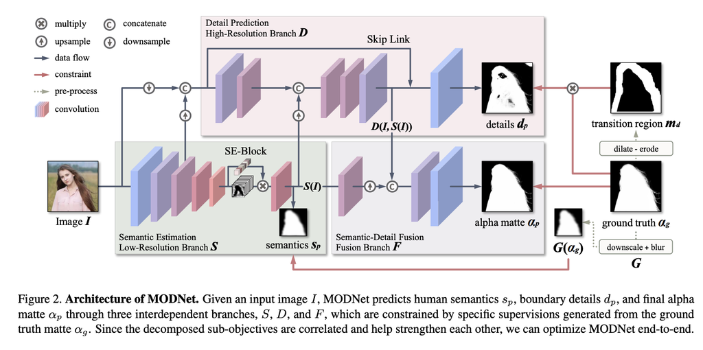

image.png

There are several other state-of-the-art models for image matting tasks, in addition to the MODNet architecture. Here are some notable ones:

1. **GCA Matting**: Proposed in 2020, the Guided Contextual Attention (GCA) model utilizes a two-stream encoder-decoder architecture with a contextual attention module. This module helps the model better capture long-range dependencies and global context information, leading to improved performance on complex scenes.
2. **AlphaMatting**: Introduced in 2021, AlphaMatting is a transformer-based model that leverages the self-attention mechanism to effectively capture long-range dependencies in images. It achieves impressive results, particularly in handling highly complicated backgrounds and foreground objects with intricate structures.
3. **SHM Matting**: The Spatially-Hierarchical Matting (SHM) model, proposed in 2022, employs a hierarchical architecture that processes the input image at multiple spatial scales. This approach helps the model capture both fine-grained details and global structures, leading to improved accuracy, especially around object boundaries.
4. **BGMatting**: Introduced in 2022, BGMatting (Background Matting) is a two-stage model that first predicts a coarse alpha matte and then refines it using a background estimation module. This unique approach helps the model better handle challenging cases with complex backgrounds or semi-transparent objects.
5. **HDMatt**: The High-Definition Matting (HDMatt) model, introduced in 2022, is designed to produce high-resolution alpha mattes by leveraging a progressive upsampling strategy. It achieves impressive results, particularly for high-resolution images, while maintaining a relatively lightweight architecture.

These models represent some of the latest advancements in the field of image matting, each with its own unique architectural design and strengths. The choice of model often depends on factors such as the complexity of the scenes, the required level of detail, and the computational resources available.

## 2. Preparation

In the top menu of this session, select **Runtime -> Change runtime type**, and set **Hardware Accelerator** to **GPU**.

Clone the repository, and download the pre-trained model:

First we import the os module, which provides functions for interacting with the operating system.

## Note: This was originally done in a Google Colab notebook. There are certain functionalities (commands like downloading from Google Drive, navigating through Colab) that are not possible to exactly replicate here. As a result, I have placed images of the Colab Notebook instead.

[figure not shown]

ColabImage1

## 3. Upload Images

[figure not shown]

## 4. Inference

[figure not shown]

ColabImage4

## 5. Visualization

[figure not shown]

`combined_display`, takes an image and its corresponding matte (alpha channel) as inputs and returns two images: one for combined display and the other for the middle image (foreground).

Here’s what each part of the function does:

1. **Calculate Display Resolution:**
   - It calculates the display resolution for the output image.
   - `w` and `h` store the width and height of the input image, respectively.
   - `rw` is set to 800, indicating the desired width for the output image.
   - `rh` is calculated to maintain the aspect ratio of the input image.
2. **Obtain Predicted Foreground:**
   - Convert the input image and matte to NumPy arrays (`image` and `matte`).
   - Check if the input image is grayscale or has an alpha channel. If so, convert it to a 3-channel image.
   - Repeat the matte across channels and normalize it.
   - Calculate the predicted foreground by applying the matte to the input image.
3. **Combine Image, Foreground, and Matte:**
   - Concatenate the input image, predicted foreground, and matte along the horizontal axis.
   - Convert the combined array back to an image (`Image.fromarray`) and resize it to the calculated resolution.
4. **Extract Middle Image:**
   - Convert the predicted foreground array to an image (`Image.fromarray`) to extract the middle image.
5. **Return Output:**
   - Return the combined display image and the middle image.

Here’s the explanation of the return values: - `combined`: The combined image showing the original image, predicted foreground, and matte (alpha channel) concatenated horizontally. - `middle_image`: The image representing the predicted foreground, extracted from the combined image.

[figure not shown]

As you can see, the first line of images corresponds to **original image, image we get, and matte(alpha)**

The second line is the image we merged with background.

Let’s break down what each part does:

### Iterating Through Image Files:

```python
image_names = os.listdir(input_folder)
for image_name in image_names:
```

- This loop iterates through each file name in the `input_folder`, which contains the input images.

### Obtaining Matte File Name:

```python
    matte_name = image_name.split('.')[0] + '.png'
```

- It extracts the file name of the matte corresponding to the current image by splitting the image file name at the ‘.’ character and appending ‘.png’ to it.

### Opening Image and Matte:

```python
    image = Image.open(os.path.join(input_folder, image_name))
    matte = Image.open(os.path.join(output_folder, matte_name))
```

- It opens the input image and matte files using `Image.open()` from the PIL library, specifying their respective paths.

### Visualizing Combined Image and Middle Image:

```python
    combined, middle_image = combined_display(image, matte)

    # Display combined image
    display(combined)

    # Display middle image
    display(middle_image)
```

- It calls the `combined_display()` function to create the combined image and extract the middle image (predicted foreground).
- Then, it displays both the combined image and the middle image using `display()`.

### Merging Middle Image with Background:

```python
    merged = Image.composite(middle_image, background_image, matte)
```

- It composites the middle image with a background image using the alpha channel provided by the matte.

### Printing Image Name:

```python
    print(image_name, '\n')
```

- It prints the name of the current image file.

### Displaying Merged Image:

```python
    display(merged)
```

- It displays the merged image, which combines the middle image with a background using the provided matte.

## 6. Implementation in Web

With all the functions we made, we want to realize it in our web. Just like this:

[figure not shown]

ColabImage9

How are we going to achieve this?

# Web Development - Jamie

In the frontend component of our web application, we have meticulously crafted a user interface allowing users to upload two distinct images: a background image and a foreground selfie. These inputs are seamlessly transmitted to the backend server through an API invocation.

On the backend infrastructure, our implementation utilizes **Node.js** in conjunction with a **JavaScript** library for subprocess management. Leveraging this architecture, we orchestrate the execution of Python scripts responsible for interfacing with our deep learning model. This model is adept at extracting foreground elements from the selfie image and seamlessly compositing them onto the provided background image. Through a series of sophisticated operations, including image analysis and processing, our system ensures high-fidelity integration of the extracted subject into the selected backdrop.

Here are some background knowledge you might need to know:

JavaScript is a high-level, interpreted programming language primarily used to create dynamic and interactive content on websites. Initially developed by Netscape as a client-side scripting language for web browsers, JavaScript has evolved into a versatile language that can be used for both client-side and server-side development.

Key features of JavaScript include:

1. **Client-Side Scripting**: JavaScript is commonly used to add interactivity to web pages, such as responding to user actions like clicks, mouse movements, form submissions, and more. It can manipulate HTML elements, dynamically change styles, and modify content on the fly.
2. **Cross-Platform**: JavaScript is supported by all modern web browsers, making it a cross-platform language. This means that code written in JavaScript will run consistently across different browsers and operating systems.
3. **Object-Oriented**: JavaScript is an object-oriented language, allowing developers to create objects with properties and methods to represent real-world entities. Objects can be defined using classes or prototypes, and inheritance is supported through prototype chaining.
4. **Asynchronous Programming**: JavaScript supports asynchronous programming using callback functions, promises, and async/await syntax. Asynchronous programming allows tasks to be executed concurrently without blocking the main thread, which is essential for handling I/O operations, such as fetching data from servers or interacting with databases.
5. **Functional Programming**: JavaScript also supports functional programming paradigms, such as higher-order functions, closures, and anonymous functions. These features enable developers to write clean, concise, and reusable code.
6. **Server-Side Development**: With the advent of server-side JavaScript frameworks like Node.js, JavaScript can now be used to build scalable and high-performance server-side applications. Node.js allows developers to run JavaScript code on the server, enabling full-stack development using a single programming language.

Overall, JavaScript is a versatile language that is widely used for web development, ranging from simple scripts to complex web applications. Its popularity and extensive ecosystem of libraries and frameworks make it an essential tool for modern web development.

Node.js is an open-source, cross-platform JavaScript runtime environment that allows developers to run JavaScript code outside of a web browser. It is built on the V8 JavaScript engine, which is the same engine that powers Google Chrome.

Node.js enables developers to write server-side applications in JavaScript, making it possible to use JavaScript for both client-side and server-side programming. This is advantageous because it allows for the reuse of code and skills across different parts of a web application.

Some key features of Node.js include:

1. Asynchronous and event-driven: Node.js uses non-blocking, asynchronous I/O operations, which means it can handle many connections simultaneously without getting blocked. This makes it well-suited for building scalable and high-performance applications.
2. Single-threaded: Node.js uses a single-threaded event loop architecture, which allows it to handle many concurrent connections efficiently. It achieves concurrency by delegating I/O operations to the operating system’s kernel, freeing up the main thread to handle other tasks.
3. npm (Node Package Manager): npm is the default package manager for Node.js, providing a vast ecosystem of open-source libraries and tools that developers can use to build their applications.
4. Wide range of use cases: Node.js is commonly used for building web servers, RESTful APIs, real-time applications (such as chat applications and online gaming), streaming applications, and more.

Overall, Node.js has become a popular choice for building server-side applications due to its performance, scalability, and the ease of using JavaScript for both client-side and server-side development.

This is the structure of the file on GitHub:

[figure not shown]

And here’s the structure of the backend:

[figure not shown]

### How to run the web application on your computer?

**Step 1: Prepare the Node Environment**

1. Visit the official Node.js website at https://nodejs.org and download the installer suitable for your operating system (Windows, macOS, or Linux). Once downloaded, locate the installer file and execute it, following the on-screen instructions for installation.
2. To ensure that Node.js has been installed correctly, open a terminal and execute the command `node -v`. This command will display the installed version of Node.js on your system.

**Step 2: Start the Backend Server**

Navigate to the `/backend-main` folder in a terminal session.

1. Create a `.env` file within this directory containing the MongoDB USERNAME and PASSWORD required for database connectivity.

```
USERNAME=jamieluo
PASSWORD=oFWMJnNpsd9i0Gvp
```

2. Execute the command `npm install` to install the project dependencies.
3. Run the command `npm run dev` to start the backend server, establishing a connection to the MongoDB server and enabling it to listen for incoming requests from the frontend.

**Step 3: Start the Frontend Server**

Navigate to the `/frontend-main` folder in another terminal session.

1. Execute the command `npm install` to install the project dependencies.
2. Run the command `npm run dev` to initiate the frontend server.
3. Note: As the frontend and backend servers typically run on different ports locally, and due to browser security policies that may block cross-origin requests, we utilize a middleware to circumvent this limitation. If your frontend project is not running on port 5174, please adjust the port number in line 13 of the `/backend-main/server.js` file accordingly.
4. Upon successful execution, a link will appear in your terminal indicating the URL for accessing the frontend. Click on this link to interact with the website.

By following these steps, you can set up the Node.js environment, start the backend server, initiate the frontend server and play with our website.

Now you can see what the main page looks like with filters:

[figure not shown]

ColabImage12

When you click the login it will show:

[figure not shown]

ColabImage13

If you are a new user, it will show:

[figure not shown]

ColabImage14

And of course, as for the Photoshop page, you’ve seen it before.

# Ethical Ramifications and Concluding Remarks

We have no control over what users do with the recommendations that they receive. This could mean that, based on certain criteria, that they engage in malicious behavior on certain trails, for example, or they may attempt to monetize the results from our tool despite the fact that we’d like it to be freely available. Even if we include disclaimers, warnings, or agreements that users have to abide by, once a recommendation is generated, it’s out of our hands.

All in all, we think that we executed our project well on the technical portion. We gave users most similar trails based upon reviews and supplemented this information by merging these similar trails with the numeric data on TrailForks. We think we could improve by implementing this onto a website better such that the person does not have to open our Jupyter Files and manually input the trails they want.